# Intro to Stan for Economists

Stan model comprised of code blocks. “data”, “parameters”, and “model” blocks must be present in all Stan programs.

Order of Stan program:

- functions - define functions to use in code blocks
- data - declares data
- transformed data - make transformations of data passed above
- parameters - defines unknowns to be estimated
- transformed parameters - often preferable to transform parameters
- model - full probability model defined here
- generated quantities - generates range of outputs from the model, e.g. posterior predictions, forecasts, values of loss functions, etc.)

# Simulate model

```r
rm(list = ls())
# Load necessary libraries and set up multi-core processing
options(warn = -1 , message = -1)
library(tidyverse)
library(rstan)
options(mc.cores = parallel::detectCores())
theme_set(theme_bw())
```

Define data generating process in independent “.stan” file.

Notice:

- Stan writes C++ programs which requires static typing
- All random number generators in Stan are distribution names followed by “_rng"

Generate some values for the data and parameters with dgp function in Stan code.

```r
# Matrix of random numbers, values for beta, nu, and sigma
set.seed(42)
N = 1000                          # Number of observations
P = 10                            # Number of parameters
X = matrix( rnorm(N*P) , N , P )  # Generate NxP covariate matrix
nu = 5                            # Set degrees of freedom
sigma = 5                         # Set scale parameter
beta = rnorm(10)                  # Generate some random coefficients for recovery
# Ensure first element of beta is positive as in our chosen DGP
beta[1] = abs( beta[1] )
```

Compile Stan script using “stan_model()” and then make function available to R using “expose_stan_functions()”

```r
compiled_function = stan_model( file = "~/Desktop/R Codes/intro_stan_econ_rng_fnct.stan")
expose_stan_functions(compiled_function)
```

dgp_rng now available in R, so can use it to generate fake data.

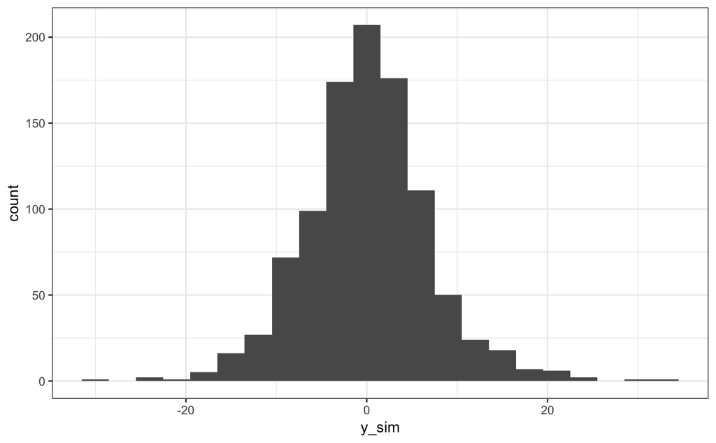

```r
# Draw vector of random numbers for knowns Xs and parameters
y_sim = dgp_rng(nu = nu , X = X , sigma = sigma , beta = beta)
# Plot data
tibble(y_sim = y_sim) %>%
  ggplot( aes(x = y_sim) ) +
  geom_histogram(binwidth = 3)
```

# Estimate simulated model

Two candidate models: specify both in Stan and estimate them.

First (incorrect) model assumes a normal distribution. Also inefficient b/c assumes that beta1 can be anything (might have reason to constrain beta1)

Estimate the two models (incorrect and correct) with the y and X previously simulated.

```r
# Specify data list to pass to Stan (laid out in data block)
data_list = list( N = N , P = P , X = X , y = y_sim )
incorrect_fit = stan(file = "~/Desktop/R Codes/intro_stan_econ_incorrect_model.stan" ,
                     data = data_list)
```

```
starting worker pid=14664 on localhost:11473 at 22:13:23.810
starting worker pid=14674 on localhost:11473 at 22:13:24.066
starting worker pid=14684 on localhost:11473 at 22:13:24.295
starting worker pid=14694 on localhost:11473 at 22:13:24.520
```

```r
correct_fit = stan(file = "~/Desktop/R Codes/intro_stan_econ_correct_model.stan" ,
                   data = data_list)
```

[output not shown]

```
recompiling to avoid crashing R session
```

```
starting worker pid=14791 on localhost:11473 at 22:14:21.775
starting worker pid=14801 on localhost:11473 at 22:14:22.020
starting worker pid=14811 on localhost:11473 at 22:14:22.262
starting worker pid=14821 on localhost:11473 at 22:14:22.511
```

Fitted Stan object contains draws for every parameter. If model fit correctly, these are from the posterior distribution.

These are draws from a joint distribution; correlation between parameters will be present in the joint posterior even if it was not present in the priors.

Also, generated quantities block contains two more variables:

- log_lik - log-likelihood for model comparison; N*(iter total) values
- y_hat - posterior predictive draw. For each parameters, this is a plausible value of corresponding y from the data model. Now, each observation has its own predictive distribution accounting for both regression residual and uncertainty in the parameter estimates.

Still premature to generate inferences from our fitted models.

Questions to ask at this stage:

- Did the estimates of the posterior distribution converge?
- Were there any other problems in the model fitting?
- Which model is better?

# Checking model fit with shinystan

Check model results with shinystan for:

- Lack of chain mixing
- Stationarity
- Autocorrelation
- Divergent transitions

```r
# Will open new Chrom tab with visualized model results
shinystan::launch_shinystan(correct_fit)
```

```
Launching ShinyStan interface... for large models this  may take some time.

Listening on http://127.0.0.1:3047
```

# Comparing models

First, check model outputs.

```r
# Specify parameter values to avoid huge output matrices include y_hat and log_lik
print( incorrect_fit , par = c("beta" , "sigma") )
```

```
Inference for Stan model: intro_stan_econ_incorrect_model.
4 chains, each with iter=2000; warmup=1000; thin=1;
post-warmup draws per chain=1000, total post-warmup draws=4000.

          mean se_mean   sd  2.5%   25%   50%   75% 97.5% n_eff Rhat
beta[1]   1.14       0 0.20  0.74  1.00  1.14  1.27  1.53 10124    1
beta[2]  -0.16       0 0.20 -0.54 -0.29 -0.16 -0.02  0.24  8479    1
beta[3]  -0.06       0 0.19 -0.45 -0.20 -0.06  0.06  0.31  7464    1
beta[4]  -0.39       0 0.20 -0.78 -0.53 -0.39 -0.26  0.01  8143    1
beta[5]   0.78       0 0.20  0.38  0.65  0.78  0.91  1.17  9737    1
beta[6]  -1.48       0 0.20 -1.86 -1.61 -1.48 -1.35 -1.11  9996    1
beta[7]   0.81       0 0.21  0.39  0.67  0.81  0.95  1.21  9880    1
beta[8]  -1.36       0 0.20 -1.74 -1.49 -1.36 -1.22 -0.97  9605    1
beta[9]   0.64       0 0.20  0.25  0.50  0.64  0.77  1.03  9657    1
beta[10] -0.11       0 0.20 -0.51 -0.25 -0.11  0.03  0.28  8282    1
sigma     6.36       0 0.14  6.09  6.26  6.35  6.45  6.64  9199    1

Samples were drawn using NUTS(diag_e) at Sat Feb 16 22:13:33 2019.
For each parameter, n_eff is a crude measure of effective sample size,
and Rhat is the potential scale reduction factor on split chains (at
convergence, Rhat=1).
```

```r
print( correct_fit , par = c("beta" , "sigma" , "nu") )
```

```
Inference for Stan model: intro_stan_econ_correct_model.
4 chains, each with iter=2000; warmup=1000; thin=1;
post-warmup draws per chain=1000, total post-warmup draws=4000.

          mean se_mean   sd  2.5%   25%   50%   75% 97.5% n_eff Rhat
beta[1]   1.09    0.00 0.18  0.73  0.96  1.08  1.21  1.44  6108    1
beta[2]  -0.08    0.00 0.18 -0.45 -0.20 -0.08  0.04  0.26  7999    1
beta[3]  -0.12    0.00 0.17 -0.46 -0.24 -0.12  0.00  0.22  6233    1
beta[4]  -0.39    0.00 0.18 -0.75 -0.51 -0.39 -0.26 -0.04  6352    1
beta[5]   0.90    0.00 0.18  0.55  0.78  0.90  1.02  1.26  6597    1
beta[6]  -1.58    0.00 0.18 -1.92 -1.69 -1.58 -1.46 -1.24  7272    1
beta[7]   0.88    0.00 0.18  0.52  0.76  0.88  1.01  1.24  6570    1
beta[8]  -1.35    0.00 0.18 -1.71 -1.48 -1.35 -1.24 -0.99  5877    1
beta[9]   0.54    0.00 0.18  0.20  0.42  0.54  0.66  0.90  7322    1
beta[10] -0.10    0.00 0.18 -0.47 -0.23 -0.10  0.02  0.26  7239    1
sigma     4.91    0.00 0.19  4.54  4.78  4.91  5.04  5.30  3692    1
nu        5.02    0.01 0.81  3.72  4.44  4.92  5.50  6.93  3442    1

Samples were drawn using NUTS(diag_e) at Sat Feb 16 22:14:33 2019.
For each parameter, n_eff is a crude measure of effective sample size,
and Rhat is the potential scale reduction factor on split chains (at
convergence, Rhat=1).
```

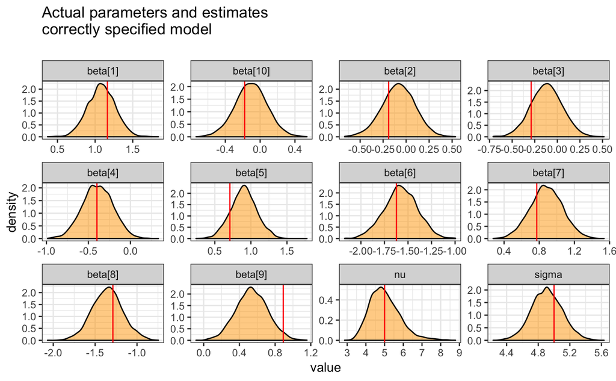

```r
# Declare a data frame that contains the known parameter names in one column `variable` and their known values
known_parameters = tibble(variable = c(paste0("beta[",1:P,"]"),"sigma", "nu"), real_value = c(beta, sigma, nu))
extract( correct_fit , permuted = FALSE , pars = c("beta" , "sigma" , "nu") ) %>%
  plyr::adply(2) %>%
  select(-chains) %>%
  gather(key = "variable") %>%
  left_join( known_parameters , by = "variable" ) %>%
  ggplot( aes(x = value) ) +
  geom_density(fill = "orange" , alpha = 0.5) +
  facet_wrap(~ variable , scales = "free") +
  geom_vline( aes(xintercept = real_value) , color = "red" ) +
  ggtitle( "Actual parameters and estimates\ncorrectly specified model\n" )
```

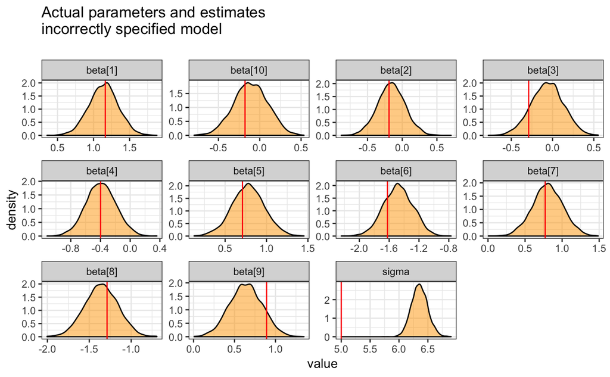

```r
# Declare a data frame that contains the known parameter names in one column `variable` and their known values
known_parameters = tibble(variable = c(paste0("beta[",1:P,"]"),"sigma"), real_value = c(beta, sigma))
extract( incorrect_fit , permuted = FALSE , pars = c("beta" , "sigma") ) %>%
  plyr::adply(2) %>%
  select(-chains) %>%
  gather(key = "variable") %>%
  left_join( known_parameters , by = "variable" ) %>%
  ggplot( aes(x = value) ) +
  geom_density(fill = "orange" , alpha = 0.5) +
  facet_wrap(~ variable , scales = "free") +
  geom_vline( aes(xintercept = real_value) , color = "red" ) +
  ggtitle( "Actual parameters and estimates\nincorrectly specified model\n" )
```

Both models do a reasonable decent job at recapturing coefficients But, normal model’s sigma parameter is way off

Makes sense: a t-distributed model has fat tails, and normal will try and capture this with wider variance.

How else can we compare our two models?

Use leave-one-out cross-validation via loo package.

```r
library(loo)
# Extract log-likelihoods of both models
llik_incorrect = extract_log_lik(incorrect_fit , parameter_name = "log_lik")
llik_correct = extract_log_lik(correct_fit , parameter_name = "log_lik")
# Estimate the leave-one-out cross-validation error
loo_incorrect = loo(llik_incorrect)
```

```
Relative effective sample sizes ('r_eff' argument) not specified.
For models fit with MCMC, the reported PSIS effective sample sizes and
MCSE estimates will be over-optimistic.
```

```r
loo_correct = loo(llik_correct)
```

```
Relative effective sample sizes ('r_eff' argument) not specified.
For models fit with MCMC, the reported PSIS effective sample sizes and
MCSE estimates will be over-optimistic.
```

```r
# Print LOO statistics
print(loo_incorrect)
```

```
Computed from 4000 by 1000 log-likelihood matrix
```

|  | Estimate | SE |
| --- | --- | --- |
| elpd_loo | -3274.5 | 35.3 |
| p_loo | 11.6 | 1.1 |
| looic | 6549.0 | 70.5 |

```
------
Monte Carlo SE of elpd_loo is 0.1.

All Pareto k estimates are good (k < 0.5).
See help('pareto-k-diagnostic') for details.
```

```r
print(loo_correct)
```

```
Computed from 4000 by 1000 log-likelihood matrix
```

|  | Estimate | SE |
| --- | --- | --- |
| elpd_loo | -3230.7 | 29.7 |
| p_loo | 11.8 | 0.4 |
| looic | 6461.4 | 59.3 |

```
------
Monte Carlo SE of elpd_loo is 0.1.

All Pareto k estimates are good (k < 0.5).
See help('pareto-k-diagnostic') for details.
```

```r
# Print the comparison between the two models
print( compare(loo_incorrect , loo_correct) )
```

```
elpd_diff        se
     43.8      14.4
```

elpd_loo is expected log pointwise predictive density, a rough analogy to log likelihood of a model.

p_loo gives effective number of parameters.

Can multiply the elpd_loo by -2 to calculate looic, which is akin to AIC/BIC. (For more on this metric, see this link: https://arxiv.org/abs/1507.04544)

elpd_diff gives us expected difference in log posterior density between the two models.

Positive value indicates more plausible predictions from second vs. first model.

# Generating posterior predictions

Use model to produce predictions.

Posterior predictions are constructed by:

- Drawing a set of parameters, theta_draw, from the posterior distribution
- For each observation i, draw a value, y_sim_i, from p(y | theta_draw, X_i)
- Repeat for all parameter draws

For each data point, we end up with as many plausible outcomes as we have draws from the posterior.

These draws take into account both the expected variation in the data model and also our posterior uncertainty.

```r
known_y = tibble( variable = paste0("y_sim[",1:N,"]"), real_y = y_sim )
plot_data = extract( correct_fit , permuted = FALSE , pars = c("y_sim") ) %>%
  plyr::adply(2) %>%
  select(-chains) %>%
  gather(key = "variable") %>%
  left_join(known_y , by = "variable") %>%
  group_by(variable) %>%
  summarize( median = median(value) ,
             lower = quantile(value , 0.025) ,
             upper = quantile(value , 0.975) ,
             actual = first(real_y) )
plot_data
```

| variable | median | lower | upper | actual |
| --- | --- | --- | --- | --- |
| y_sim[1] | -0.415843192 | -12.928166 | 11.514783 | -5.709508774 |
| y_sim[10] | -2.158615614 | -15.416377 | 10.753758 | 3.565780184 |
| y_sim[100] | 1.619333827 | -10.677378 | 14.531523 | 6.062447435 |
| y_sim[1000] | 4.006706785 | -8.913312 | 16.636308 | 8.106196347 |
| y_sim[101] | 1.139550030 | -11.562253 | 13.854220 | 2.014955971 |
| y_sim[102] | 0.619170842 | -11.992905 | 13.237299 | 8.691069944 |
| y_sim[103] | 1.737744195 | -10.840186 | 14.330494 | 1.373589959 |
| y_sim[104] | -0.353497214 | -12.954358 | 12.562539 | 0.832379543 |
| y_sim[105] | 0.621075964 | -12.565050 | 13.448798 | 12.383611383 |
| y_sim[106] | 1.894881805 | -10.556280 | 14.832191 | 1.657538079 |

[output cut: 990 more lines]

Overlay distribution as 95% predictive intervals on to actual data

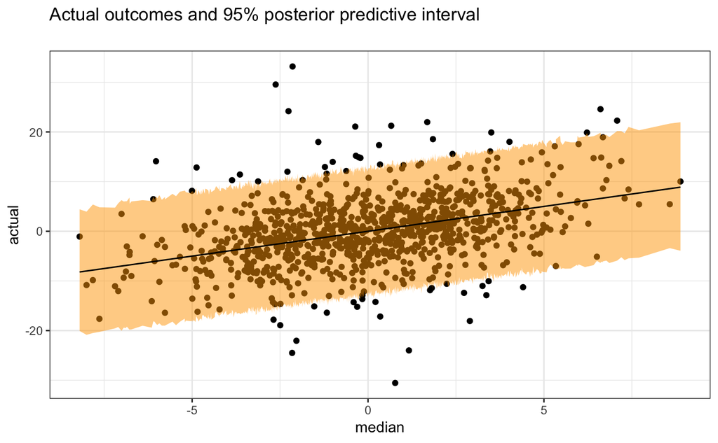

```r
plot_data %>%
    ggplot( aes(x = median) ) +
    geom_point( aes(y = actual) ) +
    geom_ribbon( aes(ymin = lower, ymax = upper) , fill = "orange" , alpha = 0.5 ) +
    geom_line( aes(y = median) ) +
    ggtitle("Actual outcomes and 95% posterior predictive interval\n")
```

Can compute the proportion of y_real that lay within the 95% posterior predictive interval

```r
plot_data %>%
  summarize( prop_within_95_pc = mean(actual >= lower & actual <= upper) )
```

| prop_within_95_pc |
| --- |
| 0.946 |

Note: If estimate generalised linear models and varying-intercept, varying-slope models, use “rstanarm” package. This package uses Stan in the back-end, but does not require the user to write Stan models.